# Test statistique sur les données Open Food Fact

Adrian Rodriguez - Projet 2 - Concevez une application au service de la santé publique

04/06/2020

```r
library(ggplot2)
library(dplyr)
```

# 1. Importation / Exploration / Visualisation des données

```r
setwd("C:/Adrian - GDrive/Formation/Informatique - Digital/OpenClassroom/Parcours/Ingénieur ML/2 - Concevez une application au service de la santé publique - 70 heures/dev")
```

```r
df = read.csv2("src/km_food.csv", sep=",", dec = ".", header=TRUE, encoding = "UTF-8")
```

```r
head(df)
```

```
##   cluster_labels                  category energy.kcal_100g
## 1              0 Epicerie - Plats préparés              108
## 2              0 Epicerie - Plats préparés              109
## 3              4         Produits laitiers              467
## 4              1 Epicerie - Plats préparés              554
## 5              0                   A trier              264
## 6              0                  Boissons               42
```

```r
str(df)
```

```
## 'data.frame':    45200 obs. of  3 variables:
##  $ cluster_labels  : int  0 0 4 1 0 0 0 4 4 4 ...
##  $ category        : Factor w/ 7 levels "A trier","Boissons",..: 3 3 4 3 1 2 6 3 5 3 ...
##  $ energy.kcal_100g: num  108 109 467 554 264 42 42 454 470 423 ...
```

```r
summary(df)
```

```
##  cluster_labels                         category     energy.kcal_100g
##  Min.   :0.000   A trier                    : 5374   Min.   :  1.0
##  1st Qu.:0.000   Boissons                   : 1186   1st Qu.:138.0
##  Median :2.000   Epicerie - Plats préparés  :13263   Median :267.0
##  Mean   :1.731   Produits laitiers          : 4832   Mean   :289.7
##  3rd Qu.:3.000   Sucrerie et produits sucrés: 5764   3rd Qu.:410.0
##  Max.   :4.000   Vegan                      : 8458   Max.   :900.0
##                  Viandes - Poissons - Oeufs : 6323
```

R a intégré les clusters comme des variables numériques. Ce sont des variables quantitatives. Je dois les factoriser afin de ne pas fausser le test statistique.

```r
df$cluster_labels = as.factor(df$cluster_labels)
str(df)
```

```
## 'data.frame':    45200 obs. of  3 variables:
##  $ cluster_labels  : Factor w/ 5 levels "0","1","2","3",..: 1 1 5 2 1 1 1 5 5 5 ...
##  $ category        : Factor w/ 7 levels "A trier","Boissons",..: 3 3 4 3 1 2 6 3 5 3 ...
##  $ energy.kcal_100g: num  108 109 467 554 264 42 42 454 470 423 ...
```

Je visualise les données

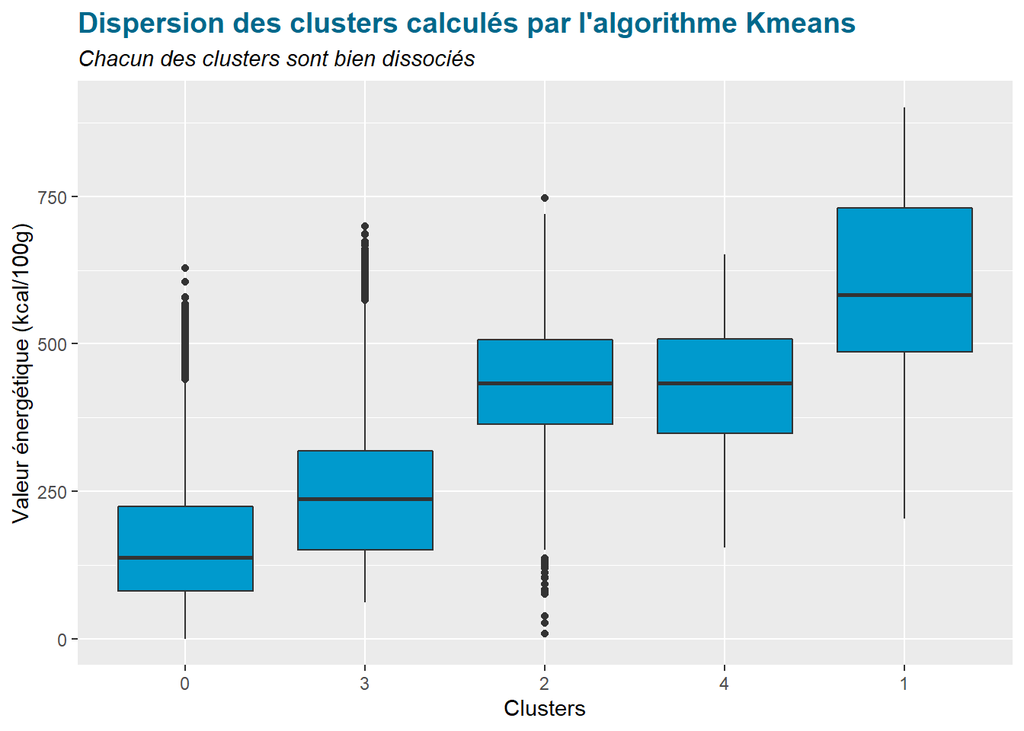

```r
# Pour afficher les clusters dans l'ordre croissant
df_order = df %>% group_by(cluster_labels) %>%
                  summarise(median = median(energy.kcal_100g)) %>%
                  arrange(median)
df$cluster_labels = factor(df$cluster_labels, levels=df_order$cluster_labels)


# Visualisation avec GGPLOT
ggplot(df, aes(df$cluster_labels, df$energy.kcal_100g)) + geom_boxplot(fill="deepskyblue3") +
      labs(title = "Dispersion des clusters calculés par l'algorithme Kmeans",
            subtitle = "Chacun des clusters sont bien dissociés",
            x="Clusters",
            y="Valeur énergétique (kcal/100g)") +
      theme(plot.title = element_text(color="deepskyblue4", size=14, face="bold"),
            plot.subtitle = element_text(face="italic"))
```

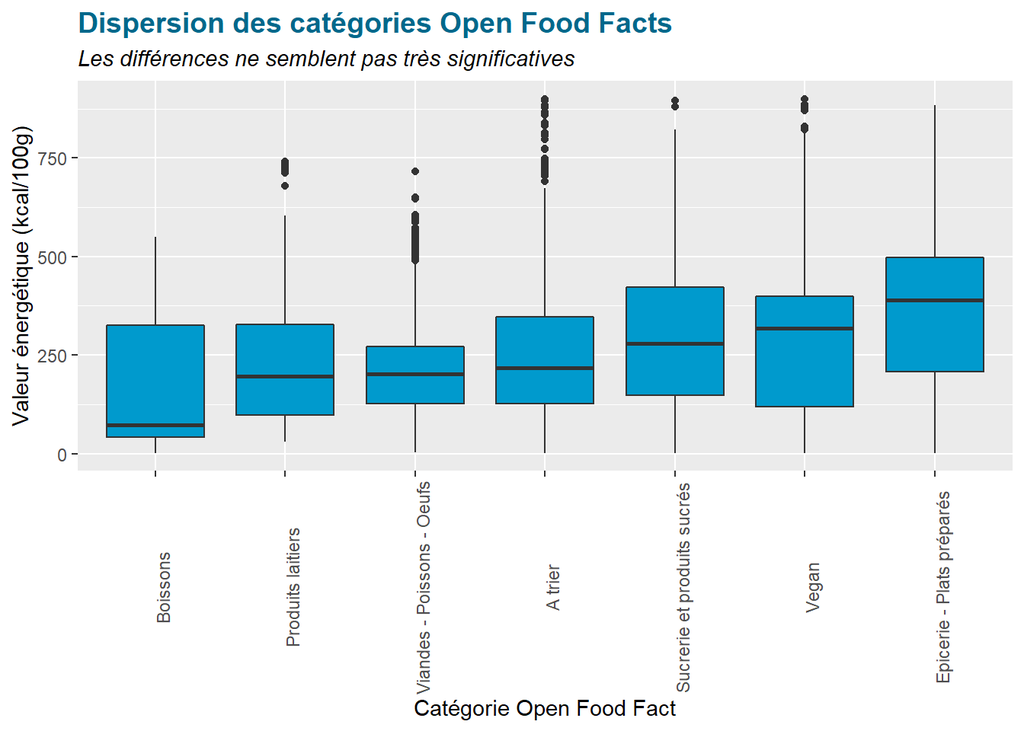

```r
# Pour afficher les clusters dans l'ordre croissant
df_order = df %>% group_by(category) %>%
                  summarise(median = median(energy.kcal_100g)) %>%
                  arrange(median)
df$category = factor(df$category, levels=df_order$category)

# Visualisation avec GGPLOT
ggplot(df, aes(df$category, df$energy.kcal_100g)) + geom_boxplot(fill="deepskyblue3") +
      labs(title = "Dispersion des catégories Open Food Facts",
            subtitle = "Les différences ne semblent pas très significatives",
            x="Catégorie Open Food Fact",
            y="Valeur énergétique (kcal/100g)") +
      theme(plot.title = element_text(color="deepskyblue4", size=14, face="bold"),
            plot.subtitle = element_text(face="italic"),
            axis.text.x = element_text(angle=90))
```

# 2. Test statistique sur les clusters calculé par Kmeans

## Question biologique

Existe-t-il une différence de valeur énergétique entre les produits des différents clusters ?

## Formulation des hypothèses

H0 = Il y a égalité entre tous les clusters.  
H1 = Au moins 1 cluster est significativement différent.

## Choix du test

Nous avons une variable quantitative et une variable qualitative à 5 modalités. Nous réalisons une anova.

```r
# Exécution du test paramétrique
lm = aov(df$energy.kcal_100g~df$cluster_labels)
```

## Vérification des résidus

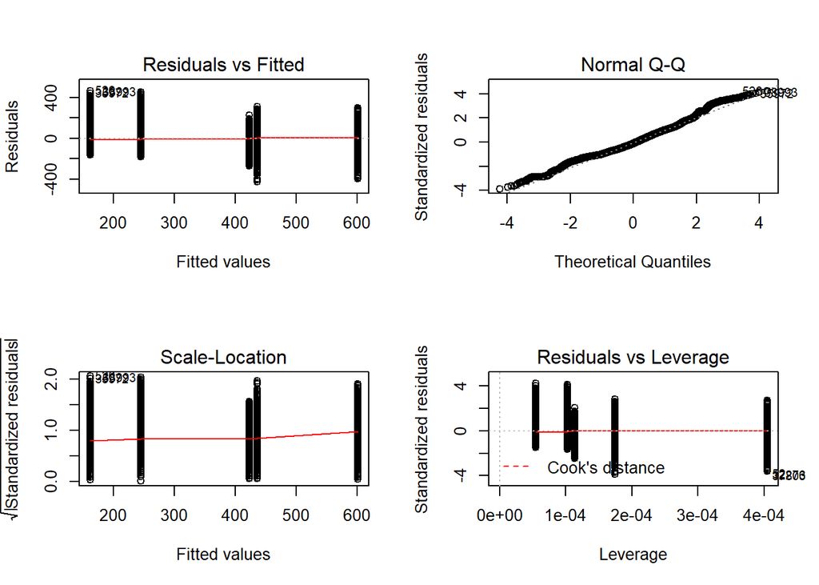

```r
par(mfrow=c(2,2))
plot(lm)
```

On constate un petit décrochage de la normalité des résidus. Mais avec 45200 observations ( > 30 observations), l’anova est capable de supporter un écart plus important. Je pourrez accepter le modèle tel quel, mais je vais m’assurer du modèle avec un test non paramètrique

Pour les autres points d’observations, il n’y a pas de tendance entre les résidus et les fitted valueset et il y a homogéneïté des variances.

## Réalisation du test non paramétrique

```r
lm_kruskal = kruskal.test(df$energy.kcal_100g~df$cluster_labels)
lm_kruskal
```

```
##
##  Kruskal-Wallis rank sum test
##
## data:  df$energy.kcal_100g by df$cluster_labels
## Kruskal-Wallis chi-squared = 26655, df = 4, p-value < 2.2e-16
```

Dans le cadre de ce test non paramètrique, la p-value est inférieur à 5 %

## Interprétation

```r
summary(lm)
```

```
##                      Df    Sum Sq   Mean Sq F value Pr(>F)
## df$cluster_labels     4 841347819 210336955   17387 <2e-16 ***
## Residuals         45195 546754416     12098
## ---
## Signif. codes:  0 '***' 0.001 '**' 0.01 '*' 0.05 '.' 0.1 ' ' 1
```

Dans les deux cas, la p-value est < 5 %. Je rejette H0. Il y a donc au moins un cluster qui est différent des autres.

## Test des moyennes 2 à 2

Pour aller plus loin, je souhaite tester 2 à 2 chacun les valeurs moyennes des clusters avec les hypothèses suivantes :  
H0: les 2 valeurs moyennes sont identiques,  
H1: les 2 valeurs moyennes sont significativement différentes.

```r
TukeyHSD(lm)
```

```
##   Tukey multiple comparisons of means
##     95% family-wise confidence level
##
## Fit: aov(formula = df$energy.kcal_100g ~ df$cluster_labels)
##
## $`df$cluster_labels`
##          diff       lwr        upr p adj
## 3-0  82.81844  79.05935  86.577534     0
## 2-0 274.44605 269.91571 278.976388     0
## 4-0 261.43818 257.54891 265.327461     0
## 1-0 439.03470 432.60929 445.460113     0
## 2-3 191.62760 186.63649 196.618714     0
## 4-3 178.61974 174.20231 183.037169     0
## 1-3 356.21626 349.45806 362.974446     0
## 4-2 -13.00787 -18.09775  -7.917983     0
## 1-2 164.58865 157.37295 171.804354     0
## 1-4 177.59652 170.76505 184.427978     0
```

Toutes les Pvalue sont inférieures à 5 %. Il existe ici une différence entre toutes les modalités.

# 3. Test statistique sur les catégories Open Food Fact

## Question biologique

Existe-t-il une différence de valeur énergétique entre les produits des différents groupe Open Food Facts ?

## Formulation des hypothèses

H0 = Il y a égalité entre tous les groupes.  
H1 = Au moins 1 groupe est significativement différent.

## Choix du test

Nous avons une variable quantitative et une variable qualitative à 7 modalités. Nous réalisons une anova.

```r
# Exécution du test paramétrique
lm = aov(df$energy.kcal_100g~df$category)
```

## Vérification des résidus

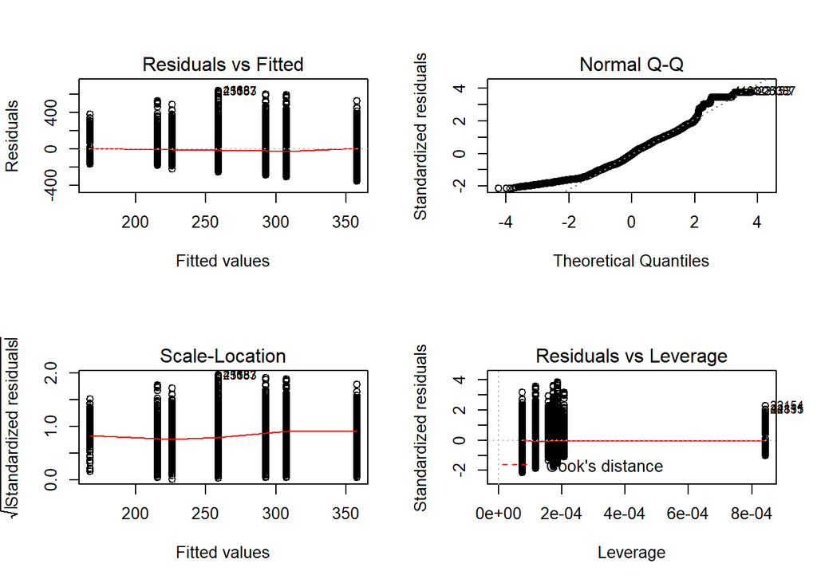

```r
par(mfrow=c(2,2))
plot(lm)
```

Pour les autres points d’observations, il n’y a pas de tendance entre les résidus et les fitted values, et il y a homogéneïté des variances.

## Réalisation du test non paramétrique

```r
lm_kruskal = kruskal.test(df$energy.kcal_100g~df$cluster_labels)
lm_kruskal
```

```
##
##  Kruskal-Wallis rank sum test
##
## data:  df$energy.kcal_100g by df$cluster_labels
## Kruskal-Wallis chi-squared = 26655, df = 4, p-value < 2.2e-16
```

## Interprétation

```r
summary(lm)
```

```
##                Df    Sum Sq  Mean Sq F value Pr(>F)
## df$category     6 1.388e+08 23136325     837 <2e-16 ***
## Residuals   45193 1.249e+09    27643
## ---
## Signif. codes:  0 '***' 0.001 '**' 0.01 '*' 0.05 '.' 0.1 ' ' 1
```

## Test des moyennes 2 à 2

Pour aller plus loin, je souhaite tester 2 à 2 chacun les valeurs moyennes des catégories avec les hypothèses suivantes :  
H0: les 2 valeurs moyennes sont identiques,  
H1: les 2 valeurs moyennes sont significativement différentes.

```r
TukeyHSD(lm)
```

```
##   Tukey multiple comparisons of means
##     95% family-wise confidence level
##
## Fit: aov(formula = df$energy.kcal_100g ~ df$category)
##
## $`df$category`
##                                                             diff        lwr
## Produits laitiers-Boissons                              48.00561  32.120514
## Viandes - Poissons - Oeufs-Boissons                     58.35608  42.844471
## A trier-Boissons                                        91.61854  75.892095
## Sucrerie et produits sucrés-Boissons                   124.99365 109.363693
## Vegan-Boissons                                         139.72936 124.530115
## Epicerie - Plats préparés-Boissons                     190.05498 175.198180
## Viandes - Poissons - Oeufs-Produits laitiers            10.35046   0.983919
## A trier-Produits laitiers                               43.61292  33.894736
## Sucrerie et produits sucrés-Produits laitiers           76.98804  67.426773
## Vegan-Produits laitiers                                 91.72375  82.884103
## Epicerie - Plats préparés-Produits laitiers            142.04937 133.812452
## A trier-Viandes - Poissons - Oeufs                      33.26246  24.167587
## Sucrerie et produits sucrés-Viandes - Poissons - Oeufs  66.63757  57.710575
## Vegan-Viandes - Poissons - Oeufs                        81.37329  73.223875
## Epicerie - Plats préparés-Viandes - Poissons - Oeufs   131.69890 124.207554
## Sucrerie et produits sucrés-A trier                     33.37511  24.079834
## Vegan-A trier                                           48.11083  39.559580
## Epicerie - Plats préparés-A trier                       98.43645  90.509828
## Vegan-Sucrerie et produits sucrés                       14.73571   6.363233
## Epicerie - Plats préparés-Sucrerie et produits sucrés   65.06133  57.327906
## Epicerie - Plats préparés-Vegan                         50.32562  43.504512
##                                                              upr     p adj
## Produits laitiers-Boissons                              63.89071 0.0000000
## Viandes - Poissons - Oeufs-Boissons                     73.86769 0.0000000
## A trier-Boissons                                       107.34498 0.0000000
## Sucrerie et produits sucrés-Boissons                   140.62361 0.0000000
## Vegan-Boissons                                         154.92861 0.0000000
## Epicerie - Plats préparés-Boissons                     204.91178 0.0000000
## Viandes - Poissons - Oeufs-Produits laitiers            19.71701 0.0192915
## A trier-Produits laitiers                               53.33111 0.0000000
## Sucrerie et produits sucrés-Produits laitiers           86.54930 0.0000000
## Vegan-Produits laitiers                                100.56339 0.0000000
## Epicerie - Plats préparés-Produits laitiers            150.28628 0.0000000
## A trier-Viandes - Poissons - Oeufs                      42.35733 0.0000000
## Sucrerie et produits sucrés-Viandes - Poissons - Oeufs  75.56457 0.0000000
## Vegan-Viandes - Poissons - Oeufs                        89.52270 0.0000000
## Epicerie - Plats préparés-Viandes - Poissons - Oeufs   139.19025 0.0000000
## Sucrerie et produits sucrés-A trier                     42.67039 0.0000000
## Vegan-A trier                                           56.66208 0.0000000
## Epicerie - Plats préparés-A trier                      106.36307 0.0000000
## Vegan-Sucrerie et produits sucrés                       23.10820 0.0000044
## Epicerie - Plats préparés-Sucrerie et produits sucrés   72.79476 0.0000000
## Epicerie - Plats préparés-Vegan                         57.14673 0.0000000
```

Toutes les Pvalue sont inférieures à 5 %. Il existe ici une différence entre toutes les modalités.  
Attention toutefois à “Viandes - Poissons - Oeufs // Produits laitiers” dont la Pvalue s’approche de 0,05.

# 4. Conclusion

L’application faisable scientifiquement faisable dans les 2 cas, que ce soit avec le clustering kmeans ou la catégorisation manuelle open food fact.